# Visualization exercise

# 1 Examine billionaires

```r
library(dplyr, warn.conflicts = FALSE, quietly = TRUE)
library(ggplot2, warn.conflicts = FALSE, quietly = TRUE)
library(readr, warn.conflicts = FALSE, quietly = TRUE)
```

# 2 Your task for this session

Write a report about the presented dataset with **at least five plots** and formulate their messages in words (interpret each plot). It is not necessary that you use a lot of different geoms, but you should make sure that each plot answers a sensible question about the data.

The purpose of this exercise is to motivate you to think about data as a trove of arguments for your imagined cause or insights in your imagined research question. This frame does not need to be very sophisticated; it’s merely there to make you think and ask questions from the data and make meaningful and interpretable plots.

The data set lists global billionaires over a time span. You can be illustrating the consequences of a hypothetical global tax on individual continents, or demonstrate societal changes on billionaires throughout decades - whatever. Negative results are fine (i.e. your plot does not prove a trend that you expected), but please describe what you were expecting to see instead, in terms of the variables rather than the visual elements (i.e., “I expected more billionaires to be under thirty” rather than “I thought the curve would begin at a lower value”).

If you get really stuck, you can peek at the source of this file (the corresponding `.qmd` file) where you will see the code chunks that generated the example plots below.

# 3 Your task for the next session

In this session, you are going to generate plenty of ideas and implement their visualizations. Note all questions to which you could not imagine (or implement) adequate plots. You are very welcome to sketch by hand plots you fancied. Together we will try to generalize your inputs and find principled solutions.

# 4 Your file and data

- Create a Quarto file named `<YOURLOGIN>_E_03_01_01.qmd` and save it in `my_exercise_scripts`.
- Replace the YAML header with the file `YAML_header_multiformat` in your ATRIUM resources folder. Mind to render an html file when you are done. Please do not use `#| echo: false` in your code chunks (leave all your code visible when rendered).
- Read file `~/R_BEGINNERS_SHORT/datasets_ATRIUM/billionaires_combined.tsv` and save it in a variable `billionaires_df`

  ```r
  billionaires_df <- read_tsv("~/R_BEGINNERS_SHORT/datasets_ATRIUM/billionaires_combined.tsv")
  ```

# 5 Billionaires counts over time, broken by sex

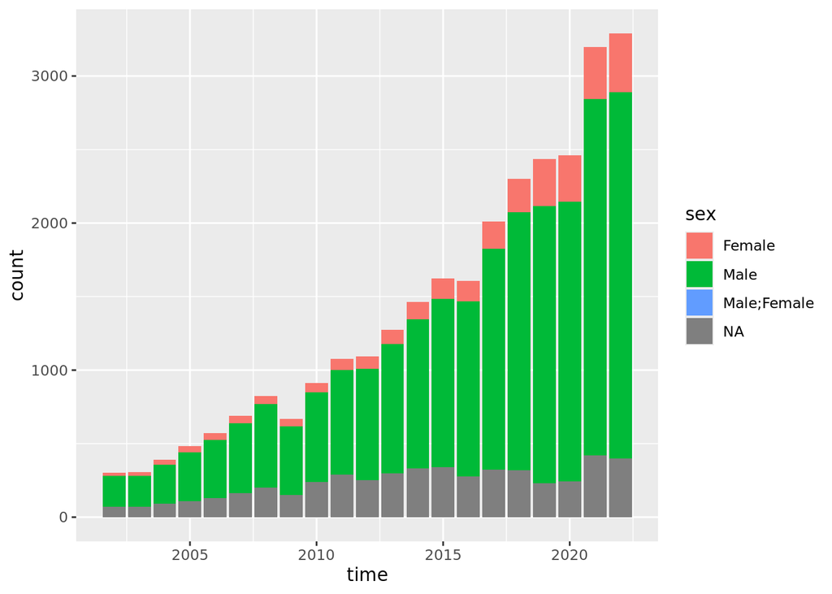

# 6 Daily income by age, sex and time

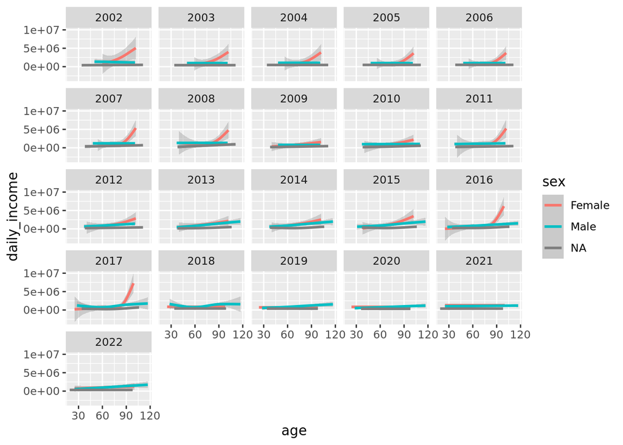

# 7 Daily income by age and sex, any time

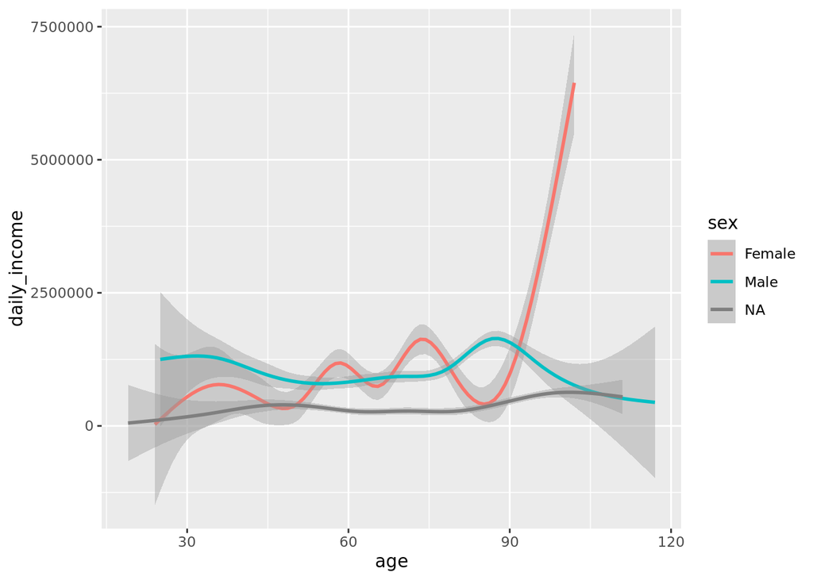

It seems that female billionaires beyond ninety are much richer than male billionaires!

Let us look at a linear model to get the most salient overall trend.

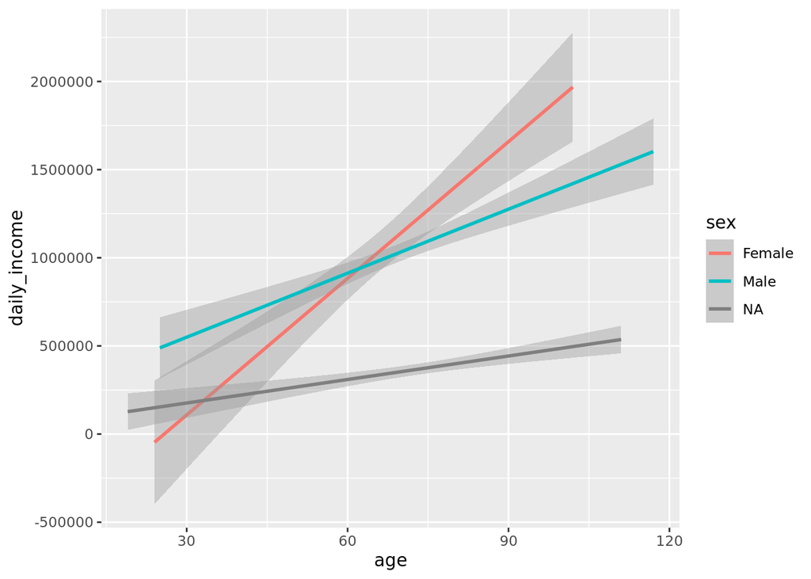

# 8 How to make a subset of the dataset

Example: Create `billionaires_2020` by filtering only year 2020.

```r
billionaires_df <- read_tsv(file = "~/R_BEGINNERS_SHORT/datasets_ATRIUM/billionaires_combined.tsv", show_col_types = FALSE)
```

```r
billionaires_2020 <- filter(billionaires_df, time == 2020)
```

# 9 Compare the count of males and female billionaires for each world region

Suggestion: barplot with dodged bars, faceted by years.

**Tilt axis text to make it legible**

When axis labels overlap, add this code and fiddle with `angle`, `hjust` (or `vjust`):

`+ theme(axis.text.x = element_text(angle = 60, hjust = 1))`

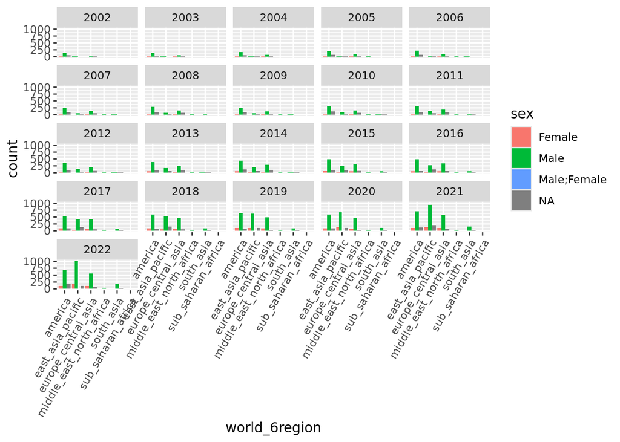

# 10 Sex, age, and residence in 2020 vs. in 2010

residence/continents $\approx$ `world_6region`

```r
billionaires_2010vs2020 <-
  filter(billionaires_df, time %in% c("2020", "2010"))
nrow(billionaires_2010vs2020)
```

```
[1] 3375
```

```r
colnames(billionaires_2010vs2020)
```

```
 [1] "person"             "time"               "daily_income"
 [4] "name.x"             "state"              "headquarters"
 [7] "source"             "industry"           "age"
[10] "gender"             "last_name"          "sex"
[13] "permanent_country"  "company"            "birth_comb"
[16] "countries"          "name.y"             "income_groups"
[19] "main_religion_2008" "world_6region"      "west_and_rest"
```

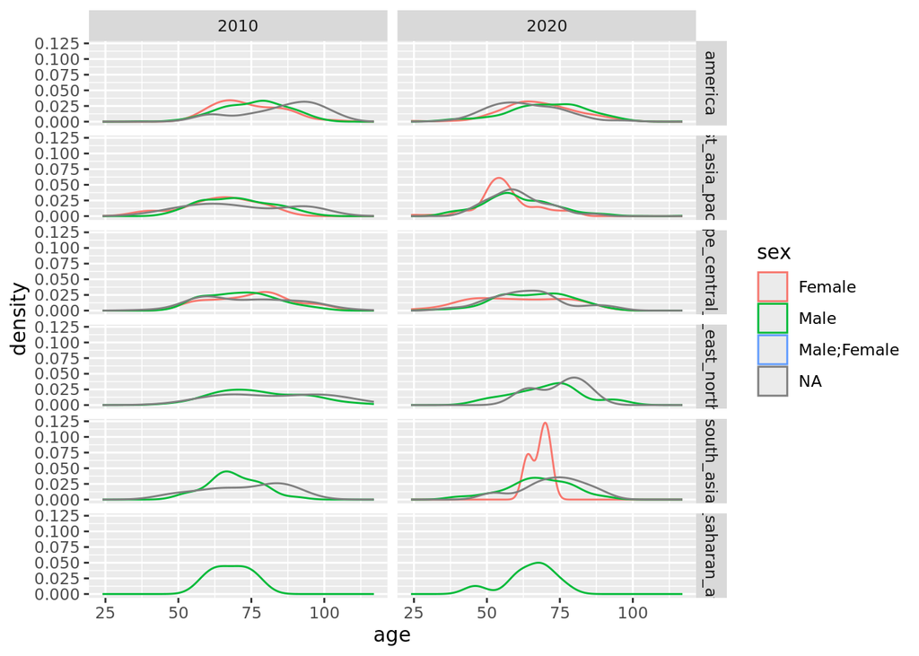

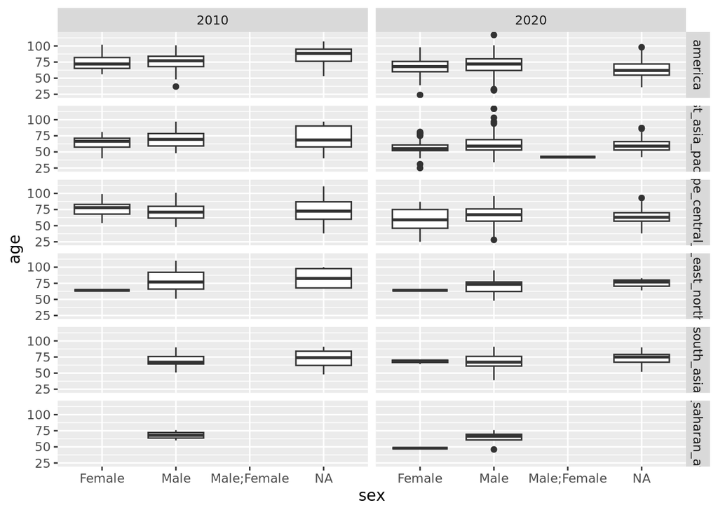

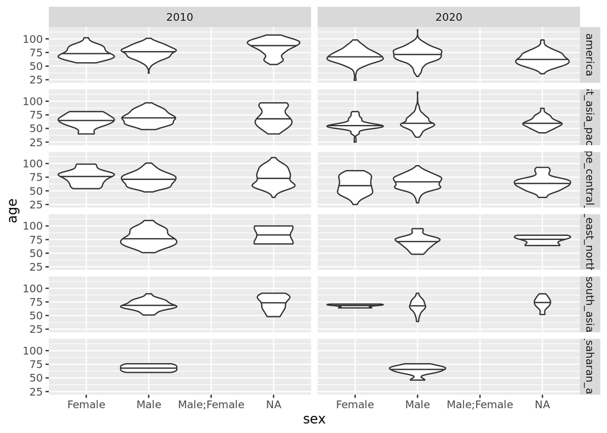

# 11 West and rest over time

Are Western billionaires richer than those from other regions? Is there any development?

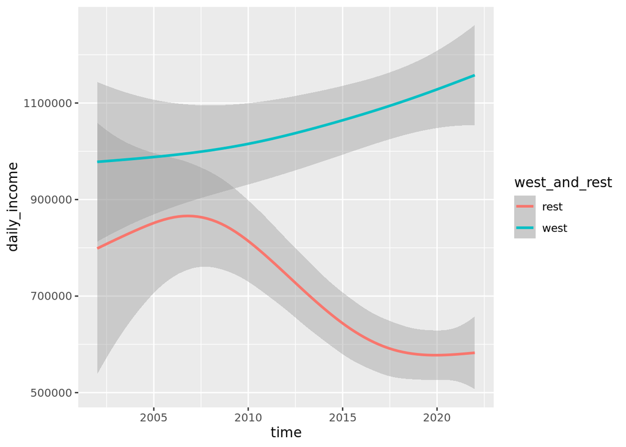